# Recommendations with IBM

#### Step 1: Find common userids and articles in both train and test datasets

```python
#We already computed the userids and articles in the testing set from above, look at shape
test_idx.shape, test_arts.shape
```

```
((682,), (574,))
```

```python
#Strip off the training rows as userid, and training columns as articles
train_idx = user_item_train.index
train_arts = user_item_train.columns
train_idx.shape, train_arts.shape
```

```
((4487,), (714,))
```

```python
#Find the intersection of userids and articles in both testing and training indices
test_user_subset = np.intersect1d(test_idx,train_idx)
test_arts_subset = np.intersect1d(test_arts,train_arts)
test_user_subset.shape, test_arts_subset.shape
```

```
((20,), (574,))
```

```python
#Since train_idx & arts are by index, locate where those indices are for the specific userids & articles
train_indexes = np.where(np.in1d(train_idx, test_user_subset))[0]
train_articles = np.where(np.in1d(train_arts, test_arts_subset))[0]
train_indexes.shape, train_articles.shape
```

```
((20,), (574,))
```

```python
# Do the same for test_idx, locate where the indices are our common test user set falls on
test_indexes = np.where(np.in1d(test_idx, test_user_subset))[0]
```

#### Step 2: Prepare the Training model

```python
# fit SVD on the user_item_train matrix
u_train, s_train, vt_train =  np.linalg.svd(user_item_train)
u_train.shape, s_train.shape, vt_train.shape
```

```
((4487, 4487), (714,), (714, 714))
```

```python
#Filter the item_user test and train matrices to only the shared test_user and test_arts subsets
# Now that we have their indices we can simply locate them

user_item_test_reduce = user_item_test.iloc[test_indexes,:]
user_item_train_reduce = user_item_train.iloc[train_indexes, train_articles]

user_item_test_reduce.shape, user_item_train_reduce.shape
```

```
((20, 574), (20, 574))
```

#### Step 3: Build out the Testing model

```python
#For our latent features we will choose at max of 570 based on our user_item column limit of 574

num_latent_feats = np.arange(10,570,10)
test_sum_errs = []
train_sum_errs = []
all_errs=[]

for k in num_latent_feats:

    # restructure with k latent features
    u_train_k, s_train_k, vt_train_k = u_train[:, :k], np.diag(s_train[:k]), vt_train[:k, :]

    u_test_k, vt_test_k = u_train_k[train_indexes,:] , vt_train_k[:,train_articles]  #training on s_train_k

    # take dot product

    user_item_train_preds = np.around(np.dot(np.dot(u_train_k, s_train_k), vt_train_k))
    user_item_test_preds = np.around(np.dot(np.dot(u_test_k, s_train_k), vt_test_k))


    # compute error for each prediction to actual value
    test_diffs = np.subtract(user_item_test_reduce, user_item_test_preds)
    train_diffs = np.subtract(user_item_train, user_item_train_preds)



    u_i_test_dims = user_item_test.shape[0]*user_item_test.shape[1]
    u_i_train_dims = user_item_train.shape[0]*user_item_train.shape[1]


    # total errors and keep track of them
    test_err = np.sum(np.sum(np.abs(test_diffs)))
    test_sum_errs.append(test_err)

    train_err = np.sum(np.sum(np.abs(train_diffs)))
    train_sum_errs.append(train_err)

    all_errs.append(1-((np.sum(user_item_test_preds)+
                        np.sum(np.sum(user_item_test)))/u_i_test_dims))
```

Let's plot them separately so we can see all the details of each graph:

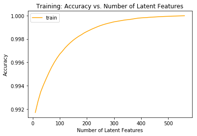

```python
plt.plot(num_latent_feats, 1 - np.array(train_sum_errs)/u_i_train_dims, label='train', color='orange');
plt.xlabel('Number of Latent Features');
plt.ylabel('Accuracy');
plt.title('Training: Accuracy vs. Number of Latent Features');
plt.legend();
```

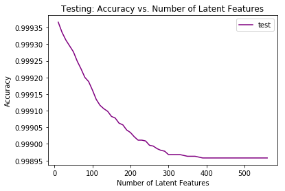

```python
plt.plot(num_latent_feats, 1 - np.array(test_sum_errs)/u_i_test_dims, label='test', color='purple');
plt.xlabel('Number of Latent Features');
plt.ylabel('Accuracy');
plt.title('Testing: Accuracy vs. Number of Latent Features');
plt.legend();
```

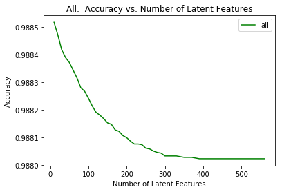

```python
plt.plot(num_latent_feats, all_errs, label='all', color='green');
plt.xlabel('Number of Latent Features');
plt.ylabel('Accuracy');
plt.title('All:  Accuracy vs. Number of Latent Features');
plt.legend();
```

`6.` Below I will comment on the results I found in the previous section. Given the circumstances of my results, I will discuss what I would do to determine if the recommendations we are making with any of the above recommendation systems are an improvement to how users currently find articles.

**Result Comments of SVD Train-Test**

It is clear the accuracy curve for the testing is almost a constant just below 1 while our training curve goes on asymptotically out. This might suggest that our model train might be overfitting and makes predictions too well on the testing data. Seems like while our model produces great results on training data it doesn't seem to generalize too well on the testing data. On these findings I would try to keep the latent features down to a minimum as it would seem to reduce the computation expense vs. the addition accuracy we are gaining.

As for using this as a recommender system, I was say it not good on its own as we only have a few users in our train-test subset and our user-item matrix is very sparse. And also the sparsness of the matrix could be why our accuracy is so high in training as it doesn't take many latent features to reproduce the original matrix.

**How to Improve Our Results**

While we didn't get the best results from our train and test of SVD, we could use this as bases to improve on how we go about improving our efforts to finding a best recommendation system. For example, if we combined the above with a ranked based system in some sort of A/B testing. This could be outlined as cookie based split invariant metric of our two groups. The 'A group' would see matrix factorized system and the 'B group' would see the ranked system which might contain features like clicks on articles, browsing time or heat map options. These would be the variant metrics of our test. The null hypothesis in this case would be there is no difference in the metrics observed. Once we verified our invariant metric (cookies) is spliting the group evenly then we would move on to evaluating the variant metrics. By checking on each metrics if they are 'statistically' significant we can make a decision if we continue to move our system into production or not.

```python
from subprocess import call
call(['python', '-m', 'nbconvert', 'Recommendations_with_IBM.ipynb'])
```

```
0
```